# Introduction to R: Homework 2 - Key

### **Instructions**

Homework is optional, but we recommend it so you can get the most out of this course.

```r
## you can add more, or change...these are suggestions
library(tidyverse)
library(readr)
library(dplyr)
library(ggplot2)
library(tidyr)
```

### **Problem Set**

1. Create the following two objects.

1. Make an object “bday”. Assign it your birthday in day-month format (1-Jan).
2. Make another object “name”. Assign it your name. Make sure to use quotation marks for anything with text!

```r
bday <- "19-Feb"
name <- "Bruce Wayne"
```

2. Make an object “me” that is “bday” and “name” combined.

```r
me <- c(bday, name)
```

3. Determine the data class for “me”.

```r
class(me)
```

```
## [1] "character"
```

```r
# The class for "me" is "character"
```

4. If I want to do `me / 2` I get the following error: `Error in me/2 : non-numeric argument to binary operator`. Why? Write your answer as a comment inside the R chunk below.

```r
# R cannot perform math functions on character data classes (types).
```

**The following questions involve an outside dataset.**

We will be working with a dataset from the “Kaggle” website, which hosts competitions for prediction and machine learning. More details on this dataset are here: https://www.kaggle.com/c/DontGetKicked/overview/background.

5. Bring the dataset into R. The dataset is located at: https://daseh.org/data/kaggleCarAuction.csv. You can use the link, download it, or use whatever method you like for getting the file. Once you get the file, read the dataset in using `read_csv()` and assign it the name `cars`.

```r
cars <- read_csv(file = "https://daseh.org/data/kaggleCarAuction.csv")
# OR
cars <- read_csv("https://daseh.org/data/kaggleCarAuction.csv")
# OR
url <- "https://daseh.org/data/kaggleCarAuction.csv"
cars <- read_csv(file = url)
# OR
download.file(
  url = "https://daseh.org/data/kaggleCarAuction.csv",
  destfile = "cars_data.csv",
  overwrite = TRUE,
  mode = "wb"
)
cars <- read_csv(file = "cars_data.csv")
```

6. Import the data “dictionary” from https://daseh.org/data/Carvana_Data_Dictionary_formatted.txt. Use the `read_tsv()` function and assign it the name “key”.

```r
key <- read_tsv(file = "https://daseh.org/data/Carvana_Data_Dictionary_formatted.txt")
# OR
download.file(
  url = "https://daseh.org/data/Carvana_Data_Dictionary_formatted.txt",
  destfile = "dict.txt",
  overwrite = TRUE,
  mode = "wb"
)
key <- read_tsv("dict.txt")
```

7. You should now be ready to work with the “cars” dataset.

1. Preview the data so that you can see the names of the columns. There are several possible functions to do this.
2. Determine the class of the first three columns using `str()`. Write your answer as a comment inside the R chunk below.

```r
str(cars)
```

```
## spc_tbl_ [72,983 × 34] (S3: spec_tbl_df/tbl_df/tbl/data.frame)
##  $ RefId                            : num [1:72983] 1 2 3 4 5 6 7 8 9 10 ...
##  $ IsBadBuy                         : num [1:72983] 0 0 0 0 0 0 0 0 0 0 ...
##  $ PurchDate                        : chr [1:72983] "12/7/2009" "12/7/2009" "12/7/2009" "12/7/2009" ...
##  $ Auction                          : chr [1:72983] "ADESA" "ADESA" "ADESA" "ADESA" ...
##  $ VehYear                          : num [1:72983] 2006 2004 2005 2004 2005 ...
##  $ VehicleAge                       : num [1:72983] 3 5 4 5 4 5 5 4 2 2 ...
##  $ Make                             : chr [1:72983] "MAZDA" "DODGE" "DODGE" "DODGE" ...
##  $ Model                            : chr [1:72983] "MAZDA3" "1500 RAM PICKUP 2WD" "STRATUS V6" "NEON" ...
##  $ Trim                             : chr [1:72983] "i" "ST" "SXT" "SXT" ...
##  $ SubModel                         : chr [1:72983] "4D SEDAN I" "QUAD CAB 4.7L SLT" "4D SEDAN SXT FFV" "4D SEDAN" ...
##  $ Color                            : chr [1:72983] "RED" "WHITE" "MAROON" "SILVER" ...
##  $ Transmission                     : chr [1:72983] "AUTO" "AUTO" "AUTO" "AUTO" ...
##  $ WheelTypeID                      : chr [1:72983] "1" "1" "2" "1" ...
##  $ WheelType                        : chr [1:72983] "Alloy" "Alloy" "Covers" "Alloy" ...
##  $ VehOdo                           : num [1:72983] 89046 93593 73807 65617 69367 ...
##  $ Nationality                      : chr [1:72983] "OTHER ASIAN" "AMERICAN" "AMERICAN" "AMERICAN" ...
##  $ Size                             : chr [1:72983] "MEDIUM" "LARGE TRUCK" "MEDIUM" "COMPACT" ...
##  $ TopThreeAmericanName             : chr [1:72983] "OTHER" "CHRYSLER" "CHRYSLER" "CHRYSLER" ...
##  $ MMRAcquisitionAuctionAveragePrice: chr [1:72983] "8155" "6854" "3202" "1893" ...
##  $ MMRAcquisitionAuctionCleanPrice  : chr [1:72983] "9829" "8383" "4760" "2675" ...
##  $ MMRAcquisitionRetailAveragePrice : chr [1:72983] "11636" "10897" "6943" "4658" ...
##  $ MMRAcquisitonRetailCleanPrice    : chr [1:72983] "13600" "12572" "8457" "5690" ...
##  $ MMRCurrentAuctionAveragePrice    : chr [1:72983] "7451" "7456" "4035" "1844" ...
##  $ MMRCurrentAuctionCleanPrice      : chr [1:72983] "8552" "9222" "5557" "2646" ...
##  $ MMRCurrentRetailAveragePrice     : chr [1:72983] "11597" "11374" "7146" "4375" ...
##  $ MMRCurrentRetailCleanPrice       : chr [1:72983] "12409" "12791" "8702" "5518" ...
##  $ PRIMEUNIT                        : chr [1:72983] "NULL" "NULL" "NULL" "NULL" ...
##  $ AUCGUART                         : chr [1:72983] "NULL" "NULL" "NULL" "NULL" ...
##  $ BYRNO                            : num [1:72983] 21973 19638 19638 19638 19638 ...
##  $ VNZIP1                           : num [1:72983] 33619 33619 33619 33619 33619 ...
##  $ VNST                             : chr [1:72983] "FL" "FL" "FL" "FL" ...
##  $ VehBCost                         : num [1:72983] 7100 7600 4900 4100 4000 5600 4200 4500 5600 7700 ...
##  $ IsOnlineSale                     : num [1:72983] 0 0 0 0 0 0 0 0 0 0 ...
##  $ WarrantyCost                     : num [1:72983] 1113 1053 1389 630 1020 ...
##  - attr(*, "spec")=
##   .. cols(
##   ..   RefId = col_double(),
##   ..   IsBadBuy = col_double(),
##   ..   PurchDate = col_character(),
```

[output cut: 18 more lines]

```
##   ..   MMRAcquisitonRetailCleanPrice = col_character(),
##   ..   MMRCurrentAuctionAveragePrice = col_character(),
##   ..   MMRCurrentAuctionCleanPrice = col_character(),
##   ..   MMRCurrentRetailAveragePrice = col_character(),
##   ..   MMRCurrentRetailCleanPrice = col_character(),
##   ..   PRIMEUNIT = col_character(),
##   ..   AUCGUART = col_character(),
##   ..   BYRNO = col_double(),
##   ..   VNZIP1 = col_double(),
##   ..   VNST = col_character(),
##   ..   VehBCost = col_double(),
##   ..   IsOnlineSale = col_double(),
##   ..   WarrantyCost = col_double()
##   .. )
##  - attr(*, "problems")=<externalptr>
```

```r
#  $ RefId                            : num [1:72983] 1 2 3 4 5 6 7 8 9 10 ...
#  $ IsBadBuy                         : num [1:72983] 0 0 0 0 0 0 0 0 0 0 ...
#  $ PurchDate                        : chr [1:72983] "12/7/2009" "12/7/2009"
# OR
# RefId = col_double()
# IsBadBuy = col_double()
# PurchDate = col_character()
```

8. How many cars (rows) are in the dataset? How many variables (columns) are recorded for each car?

```r
dim(cars)
```

```
## [1] 72983    34
```

```r
nrow(cars)
```

```
## [1] 72983
```

```r
# There are 72983 cars in the dataset and 34 variables.
```

9. Filter out (i.e., remove) any vehicles that cost less than or equal to $5000 (“VehBCost”) or that have missing values. Replace the original “cars” object by reassigning the new filtered dataset to “cars”. How many vehicles are left after filtering?

**Hint:** The `filter()` function also removes missing values.

```r
cars <- filter(cars, VehBCost > 5000)
nrow(cars)
```

```
## [1] 59957
```

```r
# OR
cars <- cars %>% filter(VehBCost > 5000)
nrow(cars)
```

```
## [1] 59957
```

```r
# There are 59957 cars after filtering by price.
```

10. From this point on, work with the filtered “cars” dataset from the above question. Given the average car loan today is 70 months, create a new variable (column) called “MonthlyPrice” that shows the monthly cost for each car (Divide “VehBCost” by 70). Check to make sure the new column is there.

**Hint:** use the `mutate()` function.

```r
cars <- cars %>% mutate(MonthlyPrice = VehBCost / 70)
# OR
cars <- mutate(cars, MonthlyPrice = VehBCost / 70)
colnames(cars)
```

```
##  [1] "RefId"                             "IsBadBuy"
##  [3] "PurchDate"                         "Auction"
##  [5] "VehYear"                           "VehicleAge"
##  [7] "Make"                              "Model"
##  [9] "Trim"                              "SubModel"
## [11] "Color"                             "Transmission"
## [13] "WheelTypeID"                       "WheelType"
## [15] "VehOdo"                            "Nationality"
## [17] "Size"                              "TopThreeAmericanName"
## [19] "MMRAcquisitionAuctionAveragePrice" "MMRAcquisitionAuctionCleanPrice"
## [21] "MMRAcquisitionRetailAveragePrice"  "MMRAcquisitonRetailCleanPrice"
## [23] "MMRCurrentAuctionAveragePrice"     "MMRCurrentAuctionCleanPrice"
## [25] "MMRCurrentRetailAveragePrice"      "MMRCurrentRetailCleanPrice"
## [27] "PRIMEUNIT"                         "AUCGUART"
## [29] "BYRNO"                             "VNZIP1"
## [31] "VNST"                              "VehBCost"
## [33] "IsOnlineSale"                      "WarrantyCost"
## [35] "MonthlyPrice"
```

11. What is the range of the manufacture year (“VehYear”) of the vehicles?

```r
range(cars %>% pull(VehYear))
```

```
## [1] 2001 2010
```

```r
# OR
car_range <- pull(cars, VehYear)
range(car_range)
```

```
## [1] 2001 2010
```

```r
# OR
range(cars$VehYear)
```

```
## [1] 2001 2010
```

```r
table(cars$VehYear)
```

```
##
##  2001  2002  2003  2004  2005  2006  2007  2008  2009  2010
##   532  1741  3859  7262 12296 15494 11079  6871   822     1
```

```r
# The range is 2001 2010.
```

12. Create a random sample with of mileage (odometer reading) from `cars`. To determine the column that corresponds to mileage (The vehicle’s odometer reading), check the “key” corresponding to the data dictionary that you imported above in question 6. Use `sample()` and `pull()`. Remember that by default random samples differ each time you run the code.

```r
sample(pull(cars, VehOdo), size = 20)
```

```
##  [1] 26524 79093 69360 80021 69820 64477 46845 86340 72295 77890 40023 50318
## [13] 83131 79430 45366 88500 82701 72262 89584 85366
```

13. How many cars were from before 2004? What percent/proportion do these represent? Use:

- `filter()` and `nrow()`
- `group_by()` and `summarize()` or
- `sum()`

```r
# How many cars were from before 2004?
nrow(cars %>% filter(VehYear < 2004))
```

```
## [1] 6132
```

```r
# OR
cars %>%
  group_by(VehYear < 2004) %>%
  summarize(total = n())
```

```
## # A tibble: 2 × 2
##   `VehYear < 2004` total
##   <lgl>            <int>
## 1 FALSE            53825
## 2 TRUE              6132
```

```r
# OR
sum(cars$VehYear < 2004)
```

```
## [1] 6132
```

```r
# OR
table(cars$VehYear < 2004)
```

```
##
## FALSE  TRUE
## 53825  6132
```

```r
# what percent/proportion do these represent?
nrow(cars %>% filter(VehYear < 2004)) / nrow(cars)
```

```
## [1] 0.1022733
```

```r
# OR
mean(cars$VehYear < 2004)
```

```
## [1] 0.1022733
```

```r
# The percent of cars were from before 2004 is 10.22733.
```

14. How many different vehicle manufacturers/makes (“Make”) are there?

**Hint:** use `length()` with `unique()` or `table()`. Remember to `pull()` the right column.

```r
cars %>%
  pull(Make) %>%
  unique() %>%
  length()
```

```
## [1] 32
```

```r
# OR
length(unique(cars %>% pull(Make)))
```

```
## [1] 32
```

```r
# OR
length(unique(cars$Make))
```

```
## [1] 32
```

```r
# OR
length(table(cars$Make))
```

```
## [1] 32
```

```r
# 32 unique makes.
```

15. How many different vehicle models (“Model”) are there?

```r
cars %>%
  pull(Model) %>%
  unique() %>%
  length()
```

```
## [1] 985
```

```r
# 985 unique models.
```

16. Which vehicle color group had the highest mean acquisition cost paid for the vehicle at time of purchase, and what was this cost?

**Hint:** Use `group_by()` with `summarize()`. To determine the column that corresponds to “acquisition cost paid for the vehicle at time of purchase”, check the “key” corresponding to the data dictionary that you imported above in question 6.

```r
cars %>%
  group_by(Color) %>%
  summarize(mean = mean(VehBCost))
```

```
## # A tibble: 17 × 2
##    Color      mean
##    <chr>     <dbl>
##  1 BEIGE     7317.
##  2 BLACK     7538.
##  3 BLUE      7182.
##  4 BROWN     7509.
##  5 GOLD      7052.
##  6 GREEN     7089.
##  7 GREY      7551.
##  8 MAROON    7220.
##  9 NOT AVAIL 7151.
## 10 NULL      5860
## 11 ORANGE    7135.
## 12 OTHER     7429.
## 13 PURPLE    6889.
## 14 RED       7279.
## 15 SILVER    7175.
## 16 WHITE     7201.
## 17 YELLOW    6922.
```

17. Extend on the code you wrote for question 16. Use the `arrange()` function to sort the output by mean acquisition cost.

```r
cars %>%
  group_by(Color) %>%
  summarize(mean = mean(VehBCost)) %>%
  arrange(desc(mean))
```

```
## # A tibble: 17 × 2
##    Color      mean
##    <chr>     <dbl>
##  1 GREY      7551.
##  2 BLACK     7538.
##  3 BROWN     7509.
##  4 OTHER     7429.
##  5 BEIGE     7317.
##  6 RED       7279.
##  7 MAROON    7220.
##  8 WHITE     7201.
##  9 BLUE      7182.
## 10 SILVER    7175.
## 11 NOT AVAIL 7151.
## 12 ORANGE    7135.
## 13 GREEN     7089.
## 14 GOLD      7052.
## 15 YELLOW    6922.
## 16 PURPLE    6889.
## 17 NULL      5860
```

18. How many vehicles were red and have fewer than 30,000 miles? To determine the column that corresponds to mileage (The vehicle’s odometer reading), check the “key” corresponding to the data dictionary that you imported above in question 6. use:

- `filter()` and `count()`
- `filter()` and `tally()` or
- `sum()`

```r
cars %>%
  filter(Color == "RED" & VehOdo < 30000) %>%
  tally()
```

```
## # A tibble: 1 × 1
##       n
##   <int>
## 1    24
```

```r
# OR
cars %>%
  filter(Color == "RED" & VehOdo < 30000) %>%
  count()
```

```
## # A tibble: 1 × 1
##       n
##   <int>
## 1    24
```

```r
# OR
sum(cars$Color == "RED" & cars$VehOdo < 30000)
```

```
## [1] 24
```

```r
# A total of 24 cars.
```

19. How many vehicles are blue or red? use:

- `filter()` and `count()`
- `filter()` and `tally()` or
- `sum()`

```r
cars %>%
  filter(Color == "BLUE" | Color == "RED") %>%
  count()
```

```
## # A tibble: 1 × 1
##       n
##   <int>
## 1 13777
```

```r
# OR
cars %>%
  filter(Color %in% c("BLUE", "RED")) %>%
  count()
```

```
## # A tibble: 1 × 1
##       n
##   <int>
## 1 13777
```

```r
# OR
sum(cars$Color == "BLUE" | cars$Color == "RED")
```

```
## [1] 13777
```

```r
# OR
sum(cars$Color %in% c("BLUE", "RED"))
```

```
## [1] 13777
```

```r
# A total of 13777 cars.
```

20. Select all columns in “cars” where the column names starts with “Veh” (using `select()` and `starts_with()`. Then, use `colMeans()` to summarize across these columns.

```r
cars %>%
  select(starts_with("Veh")) %>%
  colMeans()
```

```
##      VehYear   VehicleAge       VehOdo     VehBCost
##  2005.654252     3.896176 70336.967210  7264.971979
```

> The following questions are not required for full credit, but can make up for any points lost on other questions.

### **Bonus Practice**

A. Using “cars”, create a new binary (TRUEs and FALSEs) column to indicate if the car has an automatic transmission. Call the new column “is_automatic”.

```r
cars <- cars %>% mutate(is_automatic = (Transmission == "AUTO"))
```

B. What is the average vehicle odometer reading for cars that are both RED and NISSANs? How does this compare with vehicles that do NOT fit this criteria?

```r
mean_red_nissan <- cars %>%
  filter(Color == "RED" & Make == "NISSAN") %>%
  summarize(mean = mean(VehOdo)) %>%
  pull()

mean_not_red_nissan <- cars %>%
  filter(Color != "RED" | Make != "NISSAN") %>%
  summarize(mean = mean(VehOdo)) %>%
  pull()

# Red Nissans have an average odometer of 75117.32 while cars not fitting this criteria are 70324.34.
```

C. Among red Nissans, what is the distribution of vehicle ages?

```r
red_nissan <- cars %>% filter(Color == "RED" & Make == "NISSAN")
red_nissan %>%
  group_by(VehicleAge) %>%
  select(VehicleAge) %>%
  table()
```

```
## VehicleAge
##  2  3  4  5  6  7  8  9
##  8 35 48 34 13 14  4  2
```

```r
# OR
red_nissan <- cars %>% filter(Color == "RED" & Make == "NISSAN")
red_nissan %>%
  group_by(VehicleAge) %>%
  count()
```

```
## # A tibble: 8 × 2
## # Groups:   VehicleAge [8]
##   VehicleAge     n
##        <dbl> <int>
## 1          2     8
## 2          3    35
## 3          4    48
## 4          5    34
## 5          6    13
## 6          7    14
## 7          8     4
## 8          9     2
```

```r
# OR
red_nissan <- cars %>% filter(Color == "RED" & Make == "NISSAN")
red_nissan %>%
  group_by(VehicleAge) %>%
  tally()
```

```
## # A tibble: 8 × 2
##   VehicleAge     n
##        <dbl> <int>
## 1          2     8
## 2          3    35
## 3          4    48
## 4          5    34
## 5          6    13
## 6          7    14
## 7          8     4
## 8          9     2
```

D. How many vehicles (using `filter()` or `sum()` ) are made by Chrysler or Nissan and are white or silver?

```r
sum((cars$Make == "CHRYSLER" | cars$Make == "NISSAN") & (cars$Color == "WHITE" | cars$Color == "SILVER"))
```

```
## [1] 3718
```

```r
# OR
sum(cars$Make %in% c("CHRYSLER", "NISSAN") & cars$Color %in% c("WHITE", "SILVER"))
```

```
## [1] 3718
```

```r
# OR
cars %>%
  filter(Make %in% c("CHRYSLER", "NISSAN") & cars$Color %in% c("WHITE", "SILVER")) %>%
  count()
```

```
## # A tibble: 1 × 1
##       n
##   <int>
## 1  3718
```

```r
# A total of 3718 cars.
```

E. Make a boxplot (`boxplot()`) that looks at vehicle age (“VehicleAge”) on the x-axis and odometer reading (“VehOdo”) on the y-axis.

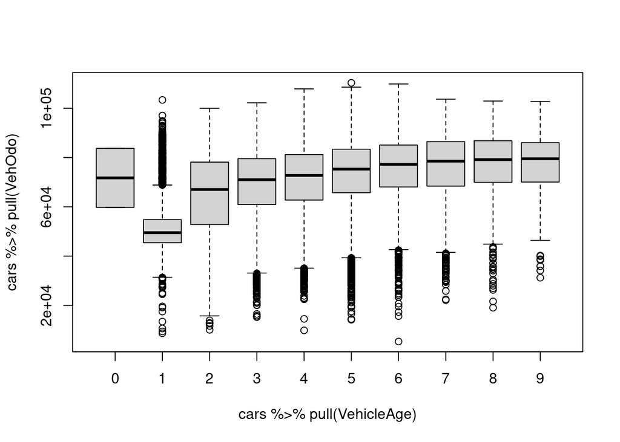

```r
boxplot(cars %>% pull(VehOdo) ~ cars %>% pull(VehicleAge))
```

F. Knit your document into a report.

You use the knit button to do this. Make sure all your code is working first!